# Predicting Exercise Quality

Dan Kirlin

February 28, 2016

# Online Versions

[Source Code](https://github.com/NLDK/ExerciseQualityPrediction/blob/master/PredictingExerciseQuality.Rmd)

[HTML Version](http://htmlpreview.github.io/?https://github.com/NLDK/ExerciseQualityPrediction/blob/master/PredictingExerciseQuality.html)

# Getting and Cleaning Data

We will start by loading the necessary libraries, as well as downloading our test and training data on disk and then into memory.

```r
library(caret); library(e1071); library(parallel);library(doParallel);
```

```r
download.file("https://d396qusza40orc.cloudfront.net/predmachlearn/pml-training.csv",destfile="training.csv",method="libcurl")
download.file("https://d396qusza40orc.cloudfront.net/predmachlearn/pml-testing.csv",destfile="testing.csv",method="libcurl")

rawTrain <- read.csv('training.csv')
test <- read.csv('testing.csv')
```

```r
keepIndices <- colSums(is.na(test)) < 2
rawTrain <- rawTrain[, keepIndices]
test <- test[, keepIndices]
```

Leveraing the knowledge from the documentation, we have even more insight into other variables of poor predictive value.

- `timestamp`: Time is irrelevant, this is fairly close to a unique identifier.
- `X`: Antoher uniqueidentifier, no predictive value.
- `user_name`: Training the model on which user was performing the exercise seems like a terrible way to overfit the data.
- `new_window`: Specifies if calculated values are present.

```r
poorPredictorIndices = grep("timestamp|X|user_name|new_window", names(rawTrain))
rawTrain <- rawTrain[, -poorPredictorIndices]
test <- test[,-poorPredictorIndices]
```

We need to build out our validation set, which will be used to calculate the out of sample error for our model towards the end of this exercise.

```r
trainingIdx <- createDataPartition(y = rawTrain$classe, p = 0.7, list = FALSE)
training <- rawTrain[trainingIdx, ]
validation <- rawTrain[-trainingIdx,]
```

# Model

For this assignment I decided to use `random forest` because although introducing **huge** computational complexity (not kidding, this thing ran for 3+ hours when the data was not cleaned up *even when multithread*) it however has highly accurate results.

## Cross Validation

For this model we will be using a 3-fold cross validation. (We are keeping the number low to keep the performance cost of training the model as low as possible.)

```r
fitControl <- trainControl(method = "cv", number = 3)
```

## Model Building

We will be doing a fairly standard random forest using the `caret` package, only difference is we will be using our custom cross-validation train control.

```r
set.seed(7354)
randomForestFit <- train(classe ~ ., data= training, method='rf', trControl=fitControl, importance = TRUE)
```

# Out of Sample Error

The Out of Sample Error (`ose`) can be given as `1 - accuracy * 100`, and we calculate it here as such.

```r
randomForestPredict <- predict(randomForestFit, validation)
ose <- (1 - (sum(randomForestPredict == validation$classe) / length(randomForestPredict))) * 100
ose
```

```
## [1] 0.03398471
```

# Visualizing

I found 3 Popular modes of visualizing random forest as pointed out on this [StackOverflow Post](http://stats.stackexchange.com/questions/2344/best-way-to-present-a-random-forest-in-a-publication), I have gone with 2 as the thrid was incompatible with the `caret` package’s `train` function (unfortunately `varImpPlot` was incompatible as well, so we’ll have to settle for a data table).

## Imporance Plot

```r
varImp(randomForestFit)
```

```
## rf variable importance
##
##   variables are sorted by maximum importance across the classes
##   only 20 most important variables shown (out of 53)
##
##                        A     B      C     D     E
## num_window        56.257 95.54 100.00 58.15 67.17
## pitch_forearm     45.726 64.35  73.60 49.33 50.38
## roll_belt         62.968 71.83  59.58 67.32 69.49
## magnet_dumbbell_z 66.834 49.40  55.75 46.61 40.87
## magnet_dumbbell_y 48.421 49.67  55.18 47.90 41.97
## pitch_belt        21.672 50.44  44.83 33.24 26.52
## yaw_belt          30.284 44.24  47.13 49.51 34.26
## accel_forearm_x   12.444 27.23  20.05 33.44 32.11
## roll_forearm      32.162 23.72  25.27 20.54 22.20
## accel_dumbbell_y  23.443 22.10  30.42 21.73 23.33
## gyros_dumbbell_y  27.818 18.76  20.45 19.97 14.56
## accel_dumbbell_z  13.260 22.08  20.04 24.28 23.43
## roll_dumbbell     12.470 21.61  15.96 17.75 23.25
## magnet_forearm_z  21.546 20.74  18.00 19.13 17.47
## magnet_belt_z      9.854 19.51  15.64 20.70 16.83
## magnet_belt_x      6.612 20.49  18.75 14.04 16.35
## yaw_arm           17.598 14.38  13.67 20.42  8.33
## magnet_belt_y     10.302 17.76  19.46 14.00 14.81
## yaw_dumbbell       8.229 19.33  11.41 13.06 13.57
## pitch_arm          5.515 17.92  12.18 13.36 18.76
```

## Overfitting with High Dimensional Data

In the following graph we can see at ~28 predictors, the random forest reaches a peak where it begins to **overfit** the data.

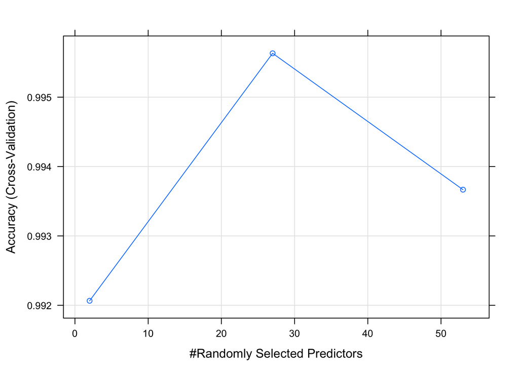

```r
plot(randomForestFit, log="y")
```